# Project: Investigate a Dataset (Tmdb-movies data )

- Introduction
- Data Wrangling
- Exploratory Data Analysis
- Conclusions

## Introduction

```python
# Use this cell to set up import statements for all of the packages that you
#   plan to use.
import pandas as pd
import numpy as np
import matplotlib.pyplot as plt
from datetime import datetime
%matplotlib inline

# Remember to include a 'magic word' so that your visualizations are plotted
#   inline with the notebook. See this page for more:
#   http://ipython.readthedocs.io/en/stable/interactive/magics.html
```

# Data Wrangling

## General Properties

### 1. The dataset contains 21 columns.

### 2. The range is from 0 to 10865 .

### 3. Null and duplicate values are present in some of the columns.

```python
# Load your data and print out a few lines. Perform operations to inspect data
#   types and look for instances of missing or possibly errant data.
df_movies=pd.read_csv('tmdb-movies.csv')#load dataset into data frame df_movies
df_movies.head(2)#shows first 2 rows of dataset.
```

|  | id | imdb_id | popularity | budget | revenue | original_title | cast | homepage | director | tagline | ... | overview | runtime | genres | production_companies | release_date | vote_count | vote_average | release_year | budget_adj | revenue_adj |
| --- | --- | --- | --- | --- | --- | --- | --- | --- | --- | --- | --- | --- | --- | --- | --- | --- | --- | --- | --- | --- | --- |
| 0 | 135397 | tt0369610 | 32.985763 | 150000000 | 1513528810 | Jurassic World | Chris Pratt\|Bryce Dallas Howard\|Irrfan Khan\|Vi... | http://www.jurassicworld.com/ | Colin Trevorrow | The park is open. | ... | Twenty-two years after the events of Jurassic ... | 124 | Action\|Adventure\|Science Fiction\|Thriller | Universal Studios\|Amblin Entertainment\|Legenda... | 6/9/15 | 5562 | 6.5 | 2015 | 1.379999e+08 | 1.392446e+09 |
| 1 | 76341 | tt1392190 | 28.419936 | 150000000 | 378436354 | Mad Max: Fury Road | Tom Hardy\|Charlize Theron\|Hugh Keays-Byrne\|Nic... | http://www.madmaxmovie.com/ | George Miller | What a Lovely Day. | ... | An apocalyptic story set in the furthest reach... | 120 | Action\|Adventure\|Science Fiction\|Thriller | Village Roadshow Pictures\|Kennedy Miller Produ... | 5/13/15 | 6185 | 7.1 | 2015 | 1.379999e+08 | 3.481613e+08 |

2 rows × 21 columns

# Data Cleaning

### 1. Columns namely tagline,homepage,keywords,imdb_id,cast,director,overview,genres and production companies had null values which were replaced by an approproate string.

### 2. There was one duplicate value which was dropped.

### 3. Datatype of release date was an object which was changed to datetime

```python
# After discussing the structure of the data and any problems that need to be
#   cleaned, perform those cleaning steps in the second part of this section.

tagline_string="no tagline" #no tagline is a string and is stored in a variable tagline_string
df_movies['tagline'].fillna(tagline_string,inplace=True)#if there is any null value in 'tagline' column then it will be replaced with string in tagline_string

homepage_string="no homepage" #no homepage is a string and is stored in a variable homepage_string
df_movies['homepage'].fillna(homepage_string,inplace=True)#if there is any null value in 'homepage' column then it will be replaced with string in homepage_string

keywords_string="no keywords" #no keywords is a string and is stored in a variable keywords_string
df_movies['keywords'].fillna(keywords_string,inplace=True)#if there is any null value in 'keywords' column then it will be replaced with string in keywords_string

imdb_id_string="no imdb_id" #no imdb_id is a string and is stored in a variable imdb_id_string
df_movies['imdb_id'].fillna(imdb_id_string,inplace=True)#if there is any null value in 'imdb_id' column then it will be replaced with string in imdb_id_string

cast_string="unknown cast" #unknown cast is a string and is stored in a variable cast_string
df_movies['cast'].fillna(cast_string,inplace=True)#if there is any null value in 'cast' column then it will be replaced with string in cast_string

director_string="unknown director" #unknown director is a string and is stored in a variable director_string
df_movies['director'].fillna(director_string,inplace=True)#if there is any null value in 'director' column then it will be replaced with string in director_string

overview_string="no overview" #no overview is a string and is stored in a variable overview_string
df_movies['overview'].fillna(overview_string,inplace=True)#if there is any null value in 'overview' column then it will be replaced with string in overview_string

genres_string="unknown genres" #unknown genres is a string and is stored in a variable genres_string
df_movies['genres'].fillna(genres_string,inplace=True)#if there is any null value in 'genres' column then it will be replaced with string in genres_string

production_comp_string="unknown production company" #unknown production company is a string and is stored in a variable production_comp_string
df_movies['production_companies'].fillna(production_comp_string,inplace=True)#if there is any null value in 'production_companies' column then it will be replaced with string in production_comp_string
```

```python
df_movies.drop_duplicates(inplace=True)#rows with duplicate values will be dropped
sum(df_movies.duplicated())#gives sum of duplicated rows,if there are no duplicate rows then sum is zero.
```

```
0
```

```python
df_movies['release_date']=pd.to_datetime(df_movies['release_date'])# converting datatype of release_date column from string to datetime
df_movies.info() #gives information like total columns,rows ,dataypes etc of dataframe.
```

```
<class 'pandas.core.frame.DataFrame'>
Int64Index: 10865 entries, 0 to 10865
Data columns (total 21 columns):
id                      10865 non-null int64
imdb_id                 10865 non-null object
popularity              10865 non-null float64
budget                  10865 non-null int64
revenue                 10865 non-null int64
original_title          10865 non-null object
cast                    10865 non-null object
homepage                10865 non-null object
director                10865 non-null object
tagline                 10865 non-null object
keywords                10865 non-null object
overview                10865 non-null object
runtime                 10865 non-null int64
genres                  10865 non-null object
production_companies    10865 non-null object
release_date            10865 non-null datetime64[ns]
vote_count              10865 non-null int64
vote_average            10865 non-null float64
release_year            10865 non-null int64
budget_adj              10865 non-null float64
revenue_adj             10865 non-null float64
dtypes: datetime64[ns](1), float64(4), int64(6), object(10)
memory usage: 1.8+ MB
```

```python
list_genres=list(set(df_movies['genres'].str.split('|').str[0]))# splits genres column strings wherever it finds '|' and returns a list of genres, nonrepeating and is stored in a list called list_genres
list_genres #displays list_genres list
```

```
['Drama',
 'History',
 'Fantasy',
 'Comedy',
 'Documentary',
 'Western',
 'Mystery',
 'Foreign',
 'Horror',
 'Music',
 'Animation',
 'Adventure',
 'Crime',
 'Family',
 'Romance',
 'TV Movie',
 'unknown genres',
 'Science Fiction',
 'War',
 'Action',
 'Thriller']
```

```python
for loc,movie in df_movies.iterrows(): #iterates over each row of df_movies dataframe.
    for genre in list_genres: #to iterate over every genre in list_genres
        df_movies.loc[loc,genre]=genre in movie['genres']#genre in genres column return index which is stored by label in loc in df_movies dataframe
```

```python
df_movies.head()#displays first 5 rows of df_movies dataframe
```

|  | id | imdb_id | popularity | budget | revenue | original_title | cast | homepage | director | tagline | ... | Adventure | Crime | Family | Romance | TV Movie | unknown genres | Science Fiction | War | Action | Thriller |
| --- | --- | --- | --- | --- | --- | --- | --- | --- | --- | --- | --- | --- | --- | --- | --- | --- | --- | --- | --- | --- | --- |
| 0 | 135397 | tt0369610 | 32.985763 | 150000000 | 1513528810 | Jurassic World | Chris Pratt\|Bryce Dallas Howard\|Irrfan Khan\|Vi... | http://www.jurassicworld.com/ | Colin Trevorrow | The park is open. | ... | True | False | False | False | False | False | True | False | True | True |
| 1 | 76341 | tt1392190 | 28.419936 | 150000000 | 378436354 | Mad Max: Fury Road | Tom Hardy\|Charlize Theron\|Hugh Keays-Byrne\|Nic... | http://www.madmaxmovie.com/ | George Miller | What a Lovely Day. | ... | True | False | False | False | False | False | True | False | True | True |
| 2 | 262500 | tt2908446 | 13.112507 | 110000000 | 295238201 | Insurgent | Shailene Woodley\|Theo James\|Kate Winslet\|Ansel... | http://www.thedivergentseries.movie/#insurgent | Robert Schwentke | One Choice Can Destroy You | ... | True | False | False | False | False | False | True | False | False | True |
| 3 | 140607 | tt2488496 | 11.173104 | 200000000 | 2068178225 | Star Wars: The Force Awakens | Harrison Ford\|Mark Hamill\|Carrie Fisher\|Adam D... | http://www.starwars.com/films/star-wars-episod... | J.J. Abrams | Every generation has a story. | ... | True | False | False | False | False | False | True | False | True | False |
| 4 | 168259 | tt2820852 | 9.335014 | 190000000 | 1506249360 | Furious 7 | Vin Diesel\|Paul Walker\|Jason Statham\|Michelle ... | http://www.furious7.com/ | James Wan | Vengeance Hits Home | ... | False | True | False | False | False | False | False | False | True | True |

5 rows × 42 columns

# Exploratory Data Analysis

## Research Question 1 (what are the top 3 genres which were most made in year 1997)

### Creating an year_genres df which contains all movie genres.

```python
# Use this, and more code cells, to explore your data. Don't forget to add
#   Markdown cells to document your observations and findings.
year_genres=df_movies.iloc[:,[18,21,22,23,24,25,26,27,28,29,30,31,32,33,34,35,36,37,38,39,40,41]]# iloc returns integer location,this will return all rows and a list of columns mentioned after colon(:)
year_genres=year_genres.set_index('release_year')# release_year column is set as index for year_genres dataframe
year_genres.head()# displays first 5 rows of year_genres dataframe
```

| release_year | Drama | History | Fantasy | Comedy | Documentary | Western | Mystery | Foreign | Horror | Music | ... | Adventure | Crime | Family | Romance | TV Movie | unknown genres | Science Fiction | War | Action | Thriller |
| --- | --- | --- | --- | --- | --- | --- | --- | --- | --- | --- | --- | --- | --- | --- | --- | --- | --- | --- | --- | --- | --- |
| 2015 | False | False | False | False | False | False | False | False | False | False | ... | True | False | False | False | False | False | True | False | True | True |
| 2015 | False | False | False | False | False | False | False | False | False | False | ... | True | False | False | False | False | False | True | False | True | True |
| 2015 | False | False | False | False | False | False | False | False | False | False | ... | True | False | False | False | False | False | True | False | False | True |
| 2015 | False | False | True | False | False | False | False | False | False | False | ... | True | False | False | False | False | False | True | False | True | False |
| 2015 | False | False | False | False | False | False | False | False | False | False | ... | False | True | False | False | False | False | False | False | True | True |

5 rows × 21 columns

### Calculating and plotting no. of individual genres made from year 1966 to 2015

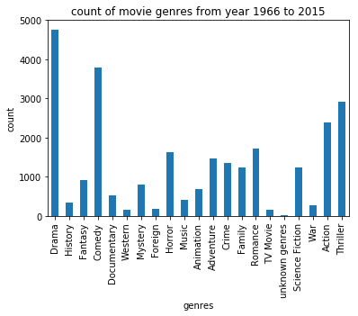

```python
year_genres.sum().plot(kind='bar');# gives sum of individual genre yearwise and plots a bar graph
plt.xlabel("genres");# gives title to x axis
plt.ylabel("count");# gives title to y axis
plt.title("count of movie genres from year 1966 to 2015"); # gives title to graph
```

### Calculating and plotting no. of individual genres made in year 1997

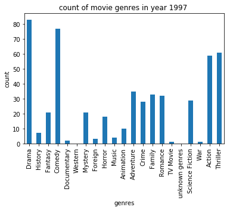

```python
year_genres.query('release_year==1997').sum().plot(kind='bar');#gives sum of individual genre for release_year 1997 and plots a bar graph
plt.xlabel("genres"); # gives title to x axis
plt.ylabel("count");# gives title to y axis
plt.title("count of movie genres in year 1997 "); # gives title to graph
```

## OBSERVATIONS

### 1. In plot 1 we observe that Comedy,Drama and Thriller are the top 3 genres in movies,that means from year 1966 to year 2015 these were the most common genres.

### 2. In plot 2 we observe that Comedy,Drama and Thriller are the top 3 genres in movies which were made in year 1997.

### 3. An interesting fact to be noted is that no Western genre movie was made in year 1997.

## Research Question 2 (In which season, movies make most revenue on average )

```python
# Continue to explore the data to address your additional research
#   questions. Add more headers as needed if you have more questions to
#   investigate.
df_movies['release_month']=df_movies['release_date'].dt.month# extracting months from release_date and creating a new column of release_month
df_movies.head(2)#displaying first 2 rows of df_movies dataframe
```

|  | id | imdb_id | popularity | budget | revenue | original_title | cast | homepage | director | tagline | ... | Crime | Family | Romance | TV Movie | unknown genres | Science Fiction | War | Action | Thriller | release_month |
| --- | --- | --- | --- | --- | --- | --- | --- | --- | --- | --- | --- | --- | --- | --- | --- | --- | --- | --- | --- | --- | --- |
| 0 | 135397 | tt0369610 | 32.985763 | 150000000 | 1513528810 | Jurassic World | Chris Pratt\|Bryce Dallas Howard\|Irrfan Khan\|Vi... | http://www.jurassicworld.com/ | Colin Trevorrow | The park is open. | ... | False | False | False | False | False | True | False | True | True | 6 |
| 1 | 76341 | tt1392190 | 28.419936 | 150000000 | 378436354 | Mad Max: Fury Road | Tom Hardy\|Charlize Theron\|Hugh Keays-Byrne\|Nic... | http://www.madmaxmovie.com/ | George Miller | What a Lovely Day. | ... | False | False | False | False | False | True | False | True | True | 5 |

2 rows × 43 columns

```python
bin_edges=[0,3,6,10,12] # Bin edges that will be used to "cut" the data into groups
bin_names=['Winter','Summer','Rainy','Autumn'] #Labels for the four seasons assigned to bin_names list
df_movies['season']=pd.cut(df_movies['release_month'],bin_edges,labels=bin_names) # Creates seasons column
df_movies.head()#dispays first 5 rows of df_movies dataframe
```

|  | id | imdb_id | popularity | budget | revenue | original_title | cast | homepage | director | tagline | ... | Family | Romance | TV Movie | unknown genres | Science Fiction | War | Action | Thriller | release_month | season |
| --- | --- | --- | --- | --- | --- | --- | --- | --- | --- | --- | --- | --- | --- | --- | --- | --- | --- | --- | --- | --- | --- |
| 0 | 135397 | tt0369610 | 32.985763 | 150000000 | 1513528810 | Jurassic World | Chris Pratt\|Bryce Dallas Howard\|Irrfan Khan\|Vi... | http://www.jurassicworld.com/ | Colin Trevorrow | The park is open. | ... | False | False | False | False | True | False | True | True | 6 | Summer |
| 1 | 76341 | tt1392190 | 28.419936 | 150000000 | 378436354 | Mad Max: Fury Road | Tom Hardy\|Charlize Theron\|Hugh Keays-Byrne\|Nic... | http://www.madmaxmovie.com/ | George Miller | What a Lovely Day. | ... | False | False | False | False | True | False | True | True | 5 | Summer |
| 2 | 262500 | tt2908446 | 13.112507 | 110000000 | 295238201 | Insurgent | Shailene Woodley\|Theo James\|Kate Winslet\|Ansel... | http://www.thedivergentseries.movie/#insurgent | Robert Schwentke | One Choice Can Destroy You | ... | False | False | False | False | True | False | False | True | 3 | Winter |
| 3 | 140607 | tt2488496 | 11.173104 | 200000000 | 2068178225 | Star Wars: The Force Awakens | Harrison Ford\|Mark Hamill\|Carrie Fisher\|Adam D... | http://www.starwars.com/films/star-wars-episod... | J.J. Abrams | Every generation has a story. | ... | False | False | False | False | True | False | True | False | 12 | Autumn |
| 4 | 168259 | tt2820852 | 9.335014 | 190000000 | 1506249360 | Furious 7 | Vin Diesel\|Paul Walker\|Jason Statham\|Michelle ... | http://www.furious7.com/ | James Wan | Vengeance Hits Home | ... | False | False | False | False | False | False | True | True | 4 | Summer |

5 rows × 44 columns

```python
season_df=df_movies.groupby('season')['revenue'].mean() #grouping season column with respect to revenue column and finding its mean which will be stored in season_df dataframe
season_df.head()# displays season_df dataframe
```

```
season
Winter    2.638043e+07
Summer    5.692919e+07
Rainy     2.997981e+07
Autumn    5.786999e+07
Name: revenue, dtype: float64
```

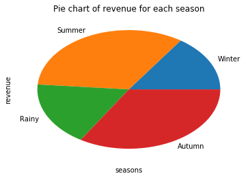

```python
season_df.plot(kind='pie');
plt.xlabel("seasons");# gives title of x axis
plt.ylabel("revenue");# gives title of y axis
plt.title("Pie chart of revenue for each season"); # gives title of graph
```

## OBSERVATIONS

### Summer and Autumn are the seasons in which movies make the most revenue on average and to be specific Autumn is the main season in which movies make the most revenue on average.

# Conclusions

### Initially, in the data wrangling plase,the dataset had 21 columns,the range of values was from 0 to 10865 ,Null and duplicate values were also present in some of the rows.

### In the data cleaning phase,null values were handled,duplicated rows were dropped and wrong datatypes of columns were corrected:-

### 1. Columns namelytagline,homepage,keywords,imdb_id,cast,director,overview,genres and production companies had null values which were replaced by an approproate string.

### 2. There was one duplicate value which was dropped.

### 3. Datatype of release date was an object which was changed to datetime.

### In Exploratory Data Analysis phase following two questions were answered:-

### Ques 1. What are the top 3 genres which were most made in year 1997

### Findings:-

### There is a list of genres like Drama,History,Fantasy,Comedy,Documentary,Western,Mystery,Foreign,Horror,Music,Animation,Adventure,Crime,Family,Romance,TV Movie,unknown genres,Science Fiction,War', Action and Thriller.

### Among which plots show and we observe that Comedy,Drama and Thriller are the top 3 genres in movies which were made in year 1997 and information to be noted here is, no Western genre movies were made in this year.

### Ques 2. In which season, movies make most revenue on average

### Findings:-

### we observe there are 4 seasons namely winter,summer,rainy and autumn ,a pie chart depicted the average revenue grossed by movies in a particular season in which average revenues were as follows:-

### Winter 2.638043e+07

### Summer 5.692919e+07

### Rainy 2.997981e+07

### Autumn 5.786999e+07

### therefore it was observed that autumn was the season which grossed highest average revenue among all the seasons.

### Limitations-this analysis cannot predict that coming years would follow the same trend i.e highest average revenue will surely be grossed in autumn season.

```python
from subprocess import call
call(['python', '-m', 'nbconvert', 'Investigate_a_Dataset.ipynb'])
```

```
0
```